# Inference of Company X and its SKU's

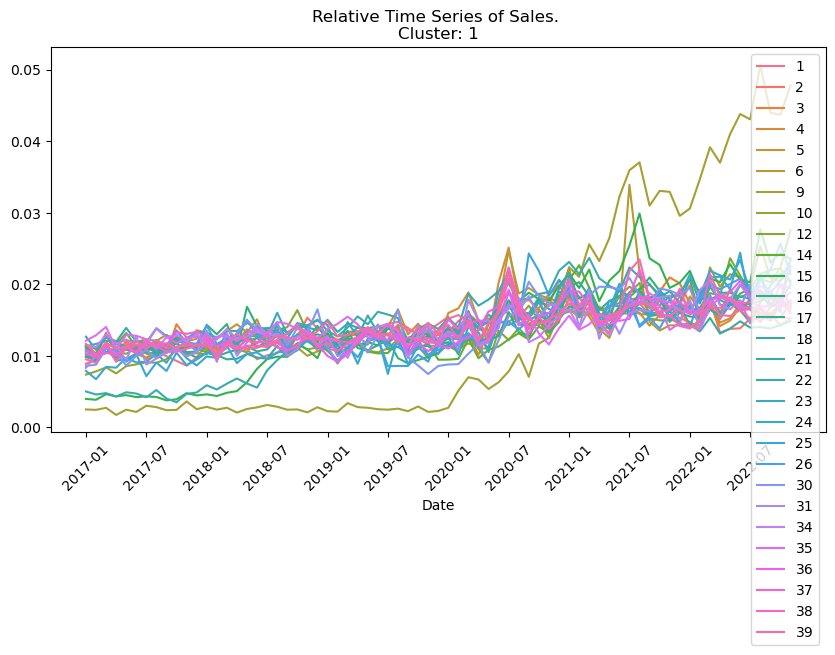

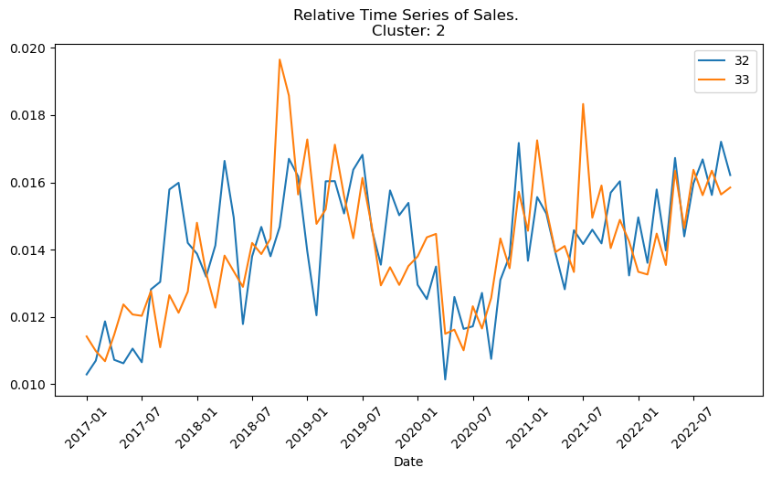

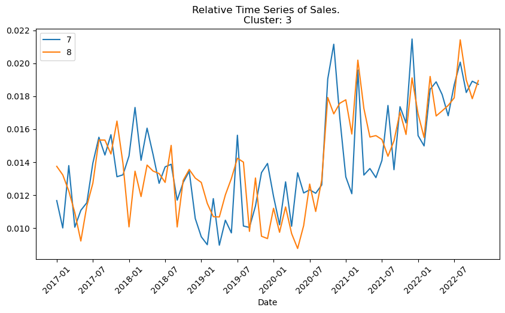

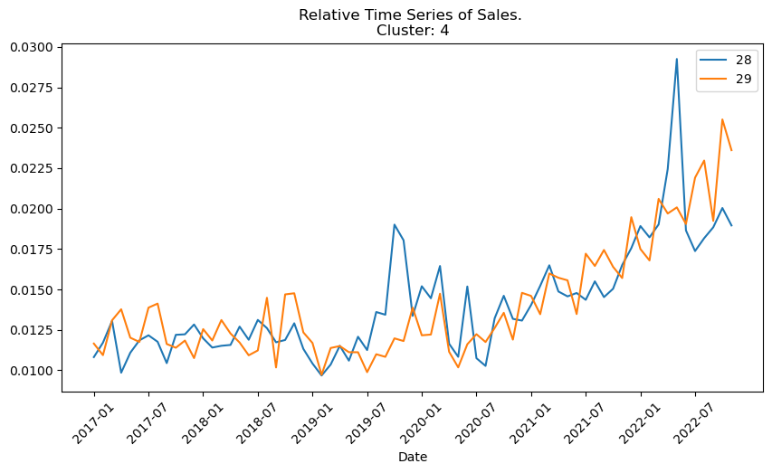

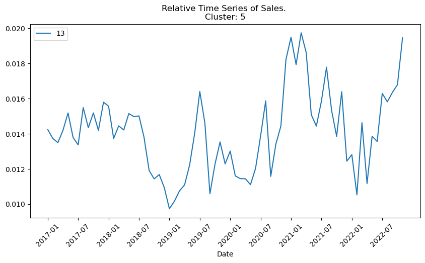

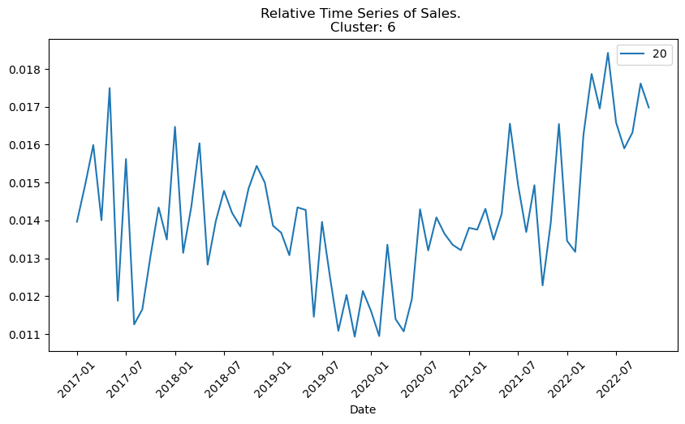

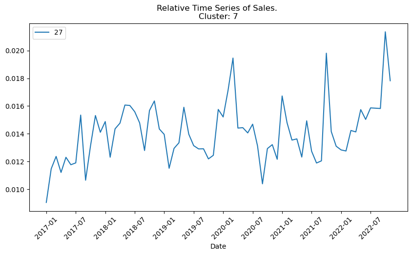

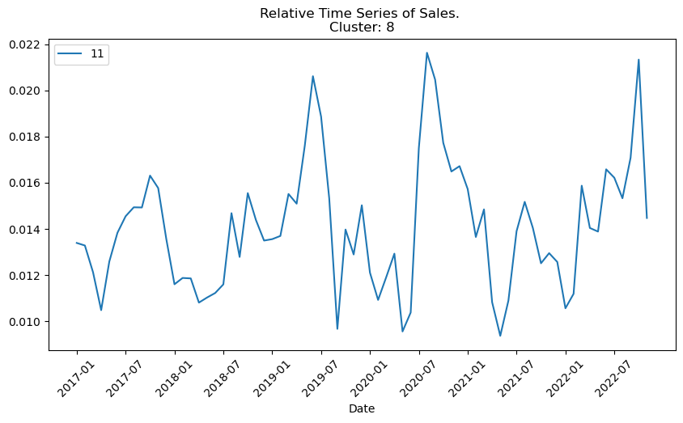

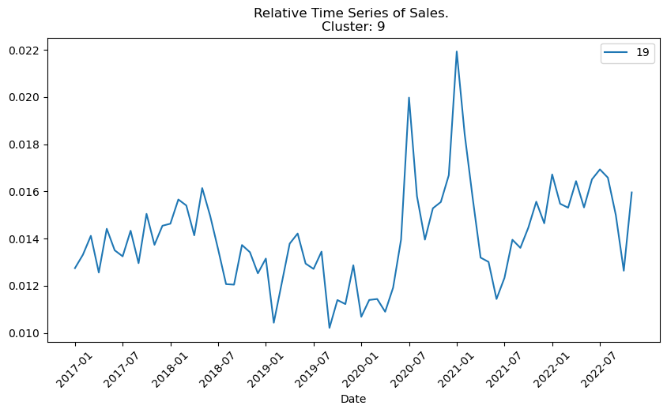

```python
# plot time series of sales for each cluster
def plot_time_series_cluster(df, cluster):
    # copy
    df = df.copy()
    # normalize the data by row
    df.iloc[:, :-1] = df.iloc[:, :-1].div(df.iloc[:, :-1].sum(axis=1), axis=0)

    # plot time series using seaborn, lines should be solid
    fig, ax = plt.subplots(figsize=(10, 5))
    sns.lineplot(data=df[df['cluster'] == cluster].iloc[:, :-1].T, dashes=False)
    # set title
    ax.set_title(f'Relative Time Series of Sales. \nCluster: {cluster}')
    # show legend
    ax.legend()
    # x ticks should be dates and only show the semester
    ax.set_xticks(df.columns[::6])
    ax.set_xticklabels(df.columns[::6], rotation=45)
    # set x label
    ax.set_xlabel('Date')

    # show plot
    plt.show()
    return None

# plot time series of sales for each cluster
for cluster in range(1, n_clusters + 1):
    plot_time_series_cluster(df_clusters, cluster)
```

```python
# show which zones are in each cluster
for cluster in range(1, n_clusters + 1):
    print(f'Cluster {cluster}: {df_clusters[df_clusters["cluster"] == cluster].index.tolist()}')
```

```
Cluster 1: [1, 2, 3, 4, 5, 6, 9, 10, 12, 14, 15, 16, 17, 18, 21, 22, 23, 24, 25, 26, 30, 31, 34, 35, 36, 37, 38, 39]
Cluster 2: [32, 33]
Cluster 3: [7, 8]
Cluster 4: [28, 29]
Cluster 5: [13]
Cluster 6: [20]
Cluster 7: [27]
Cluster 8: [11]
Cluster 9: [19]
```

**Takeaways**

1. The majority of the zones are correlated with each other. This could be due by geographical location or other factors that are common to all zones.
2. The Clusters 5 to 9 present odd behavior. Cluster 7 (zone 27) look pretty seasonal.
3. For further investigation, we could forecast the sales per cluster instead of individual zones to gain robustness.
4. The clusters are not balanced, the majority of the zones are in clusters 1. This can be by take away 1.

## SKUs by Zone

Segment the SKUs that are correlated within the zones.

```python
df_skus.T
```

| ZONA | 1 | 2 | 3 | 4 | 5 | 6 | 7 | 8 | 9 | 10 | ... | 30 | 31 | 32 | 33 | 34 | 35 | 36 | 37 | 38 | 39 |
| --- | --- | --- | --- | --- | --- | --- | --- | --- | --- | --- | --- | --- | --- | --- | --- | --- | --- | --- | --- | --- | --- |
| SKU_000001 | 1.212099 | 1.388387 | 1.779890 | 3.101737 | 1.391194 | 0.290574 | 2.431862 | 0.844616 | 0.481490 | 0.567157 | ... | 4.770411 | 2.033488 | 1.941039 | 0.230689 | 0.600878 | 1.479317 | 0.338093 | 0.779918 | 1.073363 | 2.042418 |
| SKU_000002 | 1.662853 | 0.918344 | 2.064487 | 3.063763 | 2.512046 | 1.896601 | 0.913899 | 2.840244 | 1.364216 | 3.537577 | ... | 1.903067 | 2.804788 | 2.060446 | 1.279139 | 1.657643 | 1.826742 | 2.079888 | 0.754511 | 2.563785 | 1.482821 |
| SKU_000003 | 3.136545 | 1.633432 | 1.685203 | 2.791287 | 0.619912 | 2.312037 | 0.281996 | 2.236851 | 1.434979 | 4.008739 | ... | 2.170868 | 2.290069 | 0.459806 | 3.730324 | 0.717548 | 1.539720 | 4.395514 | 2.644679 | 1.262164 | 2.175685 |
| SKU_000004 | 2.770269 | 0.595710 | 0.315957 | 0.104755 | 0.285202 | 1.425880 | 0.377118 | 0.186195 | 1.028291 | 1.877835 | ... | 2.139913 | 0.133245 | 0.237703 | 1.011045 | 0.000000 | 0.679337 | 0.543244 | 4.844704 | 0.609190 | 0.568576 |
| SKU_000005 | 6.715570 | 8.753465 | 5.675680 | 2.734516 | 16.177937 | 2.864198 | 6.173174 | 8.816835 | 0.859301 | 0.332633 | ... | 0.463770 | 2.796557 | 8.775672 | 2.447856 | 1.060049 | 3.874919 | 4.713762 | 1.400426 | 2.629919 | 5.331319 |
| ... | ... | ... | ... | ... | ... | ... | ... | ... | ... | ... | ... | ... | ... | ... | ... | ... | ... | ... | ... | ... | ... |
| SKU_000196 | 6.976844 | 1.872017 | 1.108717 | 1.507338 | 1.809659 | 7.048170 | 0.632057 | 0.927597 | 4.543479 | 2.658262 | ... | 2.587615 | 2.298817 | 0.785169 | 1.849092 | 0.269467 | 0.788080 | 3.002068 | 2.241361 | 3.090560 | 0.730717 |
| SKU_000197 | 5.182221 | 0.973966 | 0.960915 | 0.366661 | 0.125969 | 0.576043 | 1.579131 | 1.213833 | 1.532885 | 1.035147 | ... | 2.547829 | 1.429358 | 0.660587 | 0.536688 | 0.436409 | 1.030581 | 1.211235 | 0.295975 | 0.311883 | 0.892988 |
| SKU_000198 | 2.359301 | 0.632653 | 0.407213 | 0.429814 | 0.271253 | 1.169236 | 2.639629 | 0.101647 | 7.036827 | 2.585285 | ... | 1.496022 | 4.450976 | 1.554027 | 2.648890 | 4.371809 | 1.071243 | 3.567833 | 0.202734 | 1.632865 | 1.293774 |
| SKU_000199 | 0.960081 | 0.888074 | 0.996818 | 1.644299 | 2.428611 | 3.906330 | 0.560391 | 1.774998 | 0.090620 | 0.108744 | ... | 0.779330 | 2.102379 | 0.088931 | 2.391518 | 0.579858 | 2.265495 | 5.574579 | 2.066131 | 3.062949 | 3.896651 |
| SKU_000200 | 0.000000 | 0.853632 | 1.131421 | 0.487546 | 0.764751 | 0.714186 | 0.569060 | 0.365749 | 0.086411 | 0.111334 | ... | 0.756007 | 4.987268 | 4.246459 | 0.317964 | 0.880247 | 0.310483 | 4.304673 | 0.468515 | 1.474344 | 0.657999 |

200 rows × 39 columns

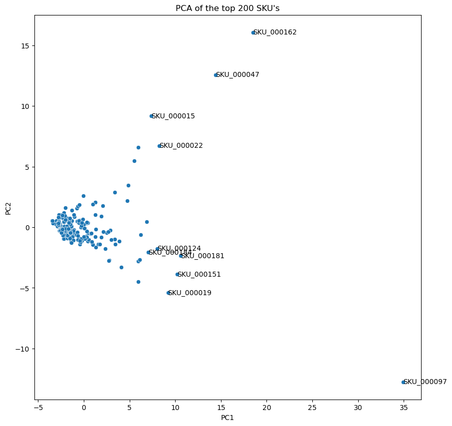

```python
# visualize top 200 sku's using PCA
from sklearn.decomposition import PCA
from sklearn.preprocessing import StandardScaler

# create the PCA object
pca = PCA(n_components=2)
# create the scaler object
scaler = StandardScaler()
# fit and transform the data
X_pca = pca.fit_transform(scaler.fit_transform(df_skus.T))
# create the dataframe
df_pca = pd.DataFrame(X_pca, index=df_skus.columns, columns=['PC1', 'PC2'])

# plot the PCA
fig, ax = plt.subplots(figsize=(10, 10))
sns.scatterplot(data=df_pca, x='PC1', y='PC2', ax=ax)
# add the sku names for the top 10 sku's with highest PC1
for sku in df_pca['PC1'].nlargest(10).index:
    ax.text(df_pca.loc[sku, 'PC1'], df_pca.loc[sku, 'PC2'], sku, ha='left', va='center')
# title
ax.set_title('PCA of the top 200 SKU\'s')
# show plot
plt.show()
```

```python
# show the PCA explained variance
print(f"Explained variance by PC1 and PC2: {100 * np.sum(pca.explained_variance_ratio_):.2f}%")
```

```
Explained variance by PC1 and PC2: 55.49%
```

Note: maybe a kmeans or any agglomerative clustering could be used to cluster the sku's. Should use dbscan to find outliers.

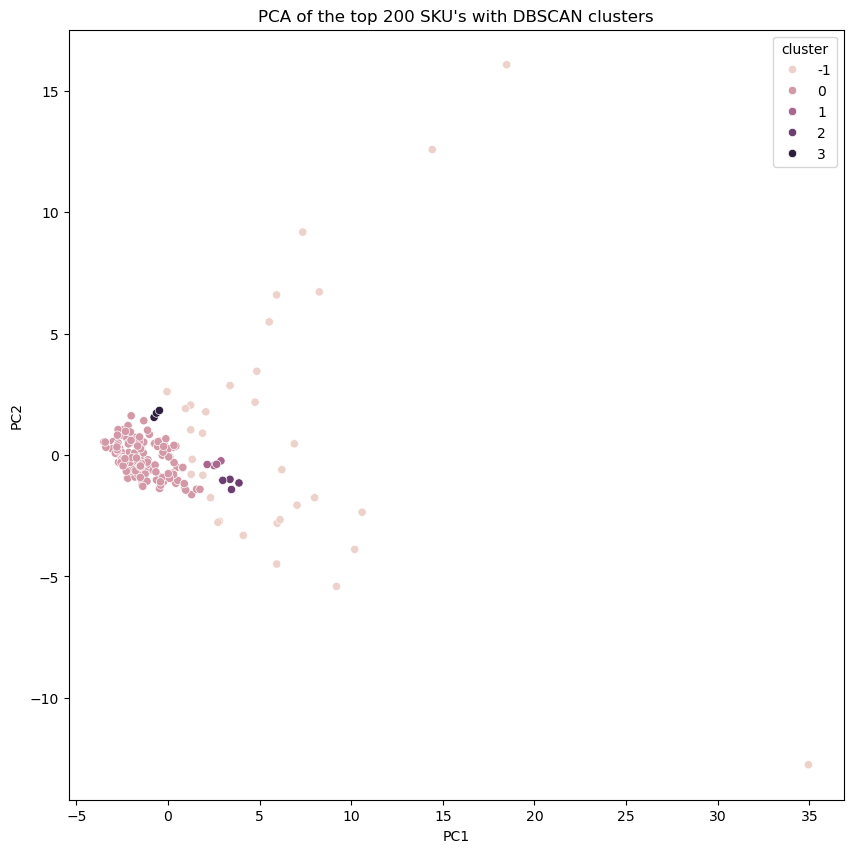

```python
# fit dbscan
from sklearn.cluster import DBSCAN

# create the dbscan object
dbscan = DBSCAN(eps=0.5, min_samples=3)
# fit the dbscan
dbscan.fit(X_pca)
# add the labels to the df_pca
df_pca['cluster'] = dbscan.labels_

# plot the PCA with the clusters
fig, ax = plt.subplots(figsize=(10, 10))
sns.scatterplot(data=df_pca, x='PC1', y='PC2', hue='cluster', ax=ax)
# title
ax.set_title('PCA of the top 200 SKU\'s with DBSCAN clusters')
# show plot
plt.show()
```

```python
# show the number of clusters
df_pca['cluster'].value_counts()
```

```
cluster
 0    156
-1     33
 1      4
 2      4
 3      3
Name: count, dtype: int64
```

```python
# for clusters 1, 2 and 3 show the sku's
for cluster in range(1, 4):
    print(f'Cluster {cluster}: {df_pca[df_pca["cluster"] == cluster].index.tolist()}')
```

```
Cluster 1: ['SKU_000005', 'SKU_000050', 'SKU_000085', 'SKU_000090']
Cluster 2: ['SKU_000094', 'SKU_000125', 'SKU_000170', 'SKU_000189']
Cluster 3: ['SKU_000128', 'SKU_000129', 'SKU_000186']
```

```python
# look cluster label of highest sales sku
print(df_pca.loc['SKU_000162', 'cluster'])
print(df_pca.loc['SKU_000047', 'cluster'])
print(df_pca.loc['SKU_000097', 'cluster'])
print(df_pca.loc['SKU_000022', 'cluster'])
print(df_pca.loc['SKU_000015', 'cluster'])
```

```
-1
-1
-1
-1
-1
```

**Takeaways**

- The sku's don't seem to have a clear structure, however there are some outliers that are worth to investigate.
- The sku's that look "similar" are the clusters 0, 1, 2 and 3.
- The cluster -1 are skus that are not correlated with any other sku. This could be due to new products or products that are not correlated with the rest of the products.
- The top selling sku's look like outliers. Maybe this indicates that products in cluster 0 are "standard" products and the top selling products are "premium" products. This could be a good strategy to increase sales to focus on the outliers.

# Recommendation System

## Sparse Matrix

```python
# input 1 if column isn't zero, 0 otherwise
df_skus_zeros = df_skus.copy().T
df_skus_zeros = df_skus_zeros.map(lambda x: x if x > 0 else np.nan)

# subset rows that have at least one nan
df_skus_zeros = df_skus_zeros[df_skus_zeros.isna().any(axis=1)]
# df_skus_zeros = df_skus_zeros[~(df_skus_zeros.prod(axis=1) > 0)]

# per row cut the data in 5 bins by quantiles
# df_skus_zeros = df_skus_zeros.apply(lambda x: pd.qcut(x, q=5, labels=False, duplicates='drop') + 1, axis=1)

# get indices of the df_skus_zeros that are nan
nan_indices = df_skus_zeros.T.isna()


df_skus_zeros.T
```

| ZONA | SKU_000004 | SKU_000006 | SKU_000012 | SKU_000048 | SKU_000060 | SKU_000083 | SKU_000084 | SKU_000093 | SKU_000098 | SKU_000107 | ... | SKU_000182 | SKU_000187 | SKU_000188 | SKU_000190 | SKU_000191 | SKU_000192 | SKU_000193 | SKU_000194 | SKU_000198 | SKU_000200 |
| --- | --- | --- | --- | --- | --- | --- | --- | --- | --- | --- | --- | --- | --- | --- | --- | --- | --- | --- | --- | --- | --- |
| 1 | 2.770269 | 0.478408 | 6.569821 | 1.697337 | 0.506494 | NaN | NaN | 3.973357 | 0.433813 | 2.281028e+01 | ... | 0.418297 | 1.677603 | 6.712063 | NaN | 1.759146 | 1.293314 | 2.408767 | 0.459970 | 2.359301 | NaN |
| 2 | 0.595710 | 0.041274 | 0.108619 | 0.190479 | 0.119700 | 3.630330 | NaN | 0.155698 | 0.381249 | 4.726417e+00 | ... | 0.777112 | 0.098419 | NaN | NaN | 0.531473 | NaN | 0.264903 | 0.107979 | 0.632653 | 0.853632 |
| 3 | 0.315957 | 0.862358 | 1.046348 | 0.811787 | 0.497736 | 0.101819 | 0.196060 | 1.179903 | 0.922547 | 4.334944e+00 | ... | 1.264701 | 0.956975 | 14.801203 | NaN | 0.346763 | NaN | 1.820579 | 0.888135 | 0.407213 | 1.131421 |
| 4 | 0.104755 | 1.642425 | 1.561254 | 0.608474 | 0.373605 | 1.518735 | 0.534028 | 5.947743 | 0.833875 | 1.663547e+01 | ... | 0.646254 | 0.478512 | 16.046328 | NaN | 0.124046 | NaN | 0.541028 | 2.645447 | 0.429814 | 0.487546 |
| 5 | 0.285202 | 0.033597 | 0.051095 | 0.045507 | 0.108830 | 0.574251 | NaN | 0.336254 | NaN | 1.246209e-01 | ... | 0.070261 | NaN | 11.464339 | NaN | 0.182338 | 1.365828 | 0.085603 | 0.262775 | 0.271253 | 0.764751 |
| 6 | 1.425880 | 0.196311 | 0.301178 | 0.201309 | 0.438563 | 4.816061 | 0.300579 | NaN | NaN | 7.885758e+00 | ... | 0.595663 | 0.492145 | 2.538861 | NaN | NaN | NaN | 0.275166 | 0.212128 | 1.169236 | 0.714186 |
| 7 | 0.377118 | 0.125277 | 0.170137 | 0.337116 | 0.106817 | NaN | 1.094807 | 0.097053 | NaN | 1.121648e+00 | ... | 0.494258 | 1.177423 | 0.313139 | 7.862011 | NaN | NaN | 0.481540 | 0.157665 | 2.639629 | 0.569060 |
| 8 | 0.186195 | 0.213508 | 2.101911 | 1.102176 | 1.249550 | 2.569130 | 0.679855 | 0.176316 | 2.931165 | 6.162019e+00 | ... | 5.049502 | 3.150935 | 13.584641 | NaN | NaN | 4.584567 | 0.444651 | 0.443136 | 0.101647 | 0.365749 |
| 9 | 1.028291 | 0.014716 | 0.134499 | 0.325096 | 0.072567 | 1.408715 | NaN | 0.032351 | 3.190101 | 2.213306e+00 | ... | 2.311335 | 0.094531 | 5.571920 | NaN | 7.062595 | 1.912830 | 0.475613 | 0.580216 | 7.036827 | 0.086411 |
| 10 | 1.877835 | 0.060504 | 0.070396 | 0.240431 | 0.047894 | 2.932211 | 1.362397 | 0.161754 | 0.069708 | 4.920427e+00 | ... | 4.486269 | 1.156220 | 1.228481 | NaN | 0.276175 | 3.818093 | 0.278766 | 0.164244 | 2.585285 | 0.111334 |
| 11 | 3.600988 | 0.834752 | 0.071287 | 1.961130 | 0.228082 | 1.177970 | 5.912888 | 3.236378 | 2.828988 | 2.040961e+01 | ... | 2.119197 | 0.665996 | 6.268098 | 78.448036 | 8.972704 | 6.320593 | 2.076044 | 0.230062 | 0.974698 | 8.065303 |
| 12 | 3.550769 | 0.136421 | 0.106281 | 0.381930 | 0.545870 | 0.471211 | 1.639430 | 0.277031 | 0.426833 | 6.596996e-01 | ... | 3.472482 | 0.383981 | 1.675770 | 5.926075 | 0.160824 | 2.210928 | 0.580886 | 0.331219 | 0.809201 | 0.883368 |
| 13 | 1.295052 | NaN | 0.188667 | 1.497158 | 0.107635 | 10.778872 | 5.543020 | 0.061467 | NaN | 9.203527e-01 | ... | 1.307313 | 2.565802 | 4.971334 | 23.620999 | 0.043723 | 3.108286 | 3.799810 | 1.725557 | 1.606611 | 0.418682 |
| 14 | 2.972554 | 0.468617 | 1.232486 | 1.948071 | 0.253263 | 4.049792 | 1.809509 | 14.066596 | 4.735043 | 5.754773e+01 | ... | 3.850232 | 3.402178 | 48.459623 | NaN | 2.405744 | 1.454671 | 3.270826 | 3.016631 | 3.028978 | 0.557945 |
| 15 | 1.761154 | 0.034063 | 0.168883 | 2.103742 | 0.108850 | 1.174997 | 0.487799 | 1.030376 | 0.377234 | 1.583073e-01 | ... | 1.467063 | 0.677464 | 1.240620 | NaN | 0.241120 | 2.016981 | 1.299416 | 1.023695 | 0.383189 | 0.125255 |
| 16 | 0.599265 | NaN | 0.027902 | 0.253016 | 0.036283 | 3.027296 | 1.866449 | 0.014705 | 0.134258 | 2.287154e-01 | ... | NaN | 0.387933 | 0.620644 | NaN | NaN | 1.625367 | 4.220364 | NaN | 0.605884 | 0.265046 |
| 17 | 0.024174 | 0.195137 | 0.143625 | 0.338707 | NaN | 1.986239 | NaN | 0.630493 | NaN | 1.017902e+00 | ... | 0.414046 | NaN | 2.212095 | NaN | 0.459538 | 0.674772 | 0.403402 | 1.836970 | 0.280494 | 1.049456 |
| 18 | 1.445183 | 0.051533 | 0.461385 | 0.093582 | 0.121584 | 1.002111 | 2.058977 | 0.280008 | 0.234995 | NaN | ... | 3.891181 | 1.999151 | 1.841253 | NaN | 0.068459 | 1.165446 | 0.201155 | 0.300242 | 0.188127 | 0.260255 |
| 19 | 1.895318 | 1.929934 | 4.181988 | 1.965412 | 0.437859 | 3.136593 | 1.646129 | 3.813010 | 7.617188 | 1.697399e+01 | ... | 2.819348 | 0.567186 | 5.529431 | NaN | 0.221914 | 0.914803 | 0.402316 | 0.225674 | 1.910203 | 0.772071 |
| 20 | 0.790094 | 0.028551 | NaN | 0.571855 | NaN | 3.365729 | 0.401184 | 3.235001 | 0.703506 | 1.381098e+01 | ... | 1.887532 | 2.393570 | 2.485343 | NaN | 1.004806 | 3.767174 | 0.100031 | 0.478813 | 2.280551 | 1.077972 |
| 21 | 0.692027 | 0.158396 | 1.031347 | 0.097505 | 0.083209 | 3.044052 | 1.174910 | 0.318240 | 0.875337 | 2.938816e+00 | ... | NaN | 1.151750 | NaN | NaN | 1.768367 | NaN | NaN | 3.300350 | 1.170440 | 0.434969 |
| 22 | 0.217971 | NaN | 0.271220 | NaN | 0.554536 | 0.421209 | NaN | NaN | 0.359319 | NaN | ... | NaN | 0.098419 | 0.293649 | NaN | NaN | NaN | 2.719309 | 0.311118 | NaN | 1.192151 |
| 23 | 2.116809 | 0.490524 | 1.454733 | 1.609191 | 0.387585 | 5.785290 | 1.330848 | 0.084028 | 0.716339 | 1.476535e+00 | ... | 0.485431 | 0.494065 | 0.158817 | NaN | NaN | 1.317503 | 0.968811 | 0.907536 | 0.502374 | 1.577624 |
| 24 | 0.253829 | 17.017256 | 17.930954 | 4.177513 | 0.369208 | 3.228805 | 1.328529 | 12.503250 | 19.716240 | 5.555496e+01 | ... | 0.218926 | 0.491564 | 31.019310 | NaN | 6.849544 | NaN | 2.261104 | 0.720087 | 23.129201 | 2.384668 |
| 25 | 0.280767 | 0.042901 | 0.115122 | 2.269796 | 0.044629 | 0.810624 | 0.817449 | 0.064702 | 0.372255 | 3.740755e-08 | ... | 1.680120 | 1.180499 | 38.844897 | NaN | 2.553566 | 1.120956 | 0.904912 | 0.331221 | 17.742720 | 7.711947 |
| 26 | 7.083275 | 1.478815 | 2.523573 | 2.541106 | 0.519673 | 4.529662 | 2.395618 | 0.095389 | 13.713068 | 1.085921e+01 | ... | 2.614586 | 0.677660 | 55.535727 | NaN | 2.467267 | 5.062928 | 0.941869 | 3.252475 | 5.490340 | 0.677638 |
| 27 | 1.361867 | 2.200794 | 0.100749 | 0.684122 | 15.990368 | 4.110186 | 3.664064 | 0.535391 | 1.677840 | 9.922962e+00 | ... | 0.434127 | 0.198807 | 4.289483 | 3.864331 | 0.022751 | 2.076748 | 0.077897 | 1.594598 | 0.580376 | 16.890779 |
| 28 | 0.448604 | 2.939551 | 12.865881 | 3.319216 | 1.386725 | 4.513885 | 0.598490 | 13.297257 | 37.327424 | 4.509247e+01 | ... | 0.638559 | 0.392081 | 57.727239 | 9.819483 | 2.571429 | 0.540539 | 2.334847 | 1.120739 | 8.212966 | 5.256192 |
| 29 | 1.567095 | 0.107742 | 0.369357 | 0.804414 | 0.018142 | 2.748212 | 2.183580 | 0.346103 | 0.156663 | 5.102866e-01 | ... | 1.902254 | 2.843064 | 2.391054 | NaN | NaN | 0.545303 | 0.469619 | 1.235202 | 0.301947 | 3.089799 |
| 30 | 2.139913 | 6.470623 | 0.094081 | 0.228338 | 9.935918 | 4.020870 | 1.097263 | 7.153318 | 0.591334 | 4.918393e+01 | ... | 4.227702 | 0.384310 | 16.317844 | NaN | NaN | 5.293154 | 2.075907 | 0.507368 | 1.496022 | 0.756007 |
| 31 | 0.133245 | 0.420599 | 2.945202 | 0.582005 | 1.176370 | 2.262708 | 0.503345 | NaN | 0.756622 | 1.886727e+00 | ... | 1.799108 | 3.818603 | 1.080879 | NaN | 1.952478 | 5.976520 | 3.030659 | 1.894636 | 4.450976 | 4.987268 |
| 32 | 0.237703 | 0.367494 | 1.890886 | 1.748536 | 13.811467 | 3.162509 | 1.207987 | 2.010573 | 0.598044 | 8.116179e+00 | ... | 0.227012 | 2.413824 | 12.978197 | 11.904271 | 0.376825 | 0.345528 | 0.421489 | 0.690251 | 1.554027 | 4.246459 |
| 33 | 1.011045 | 0.125822 | 0.476134 | 1.984977 | 1.229599 | 6.595337 | 0.388223 | 7.099603 | 1.383923 | 6.212725e+00 | ... | 0.215696 | 1.484377 | 4.731276 | 11.624724 | 1.146622 | 3.539168 | 0.443672 | 0.315331 | 2.648890 | 0.317964 |
| 34 | NaN | 0.376550 | 2.187777 | 0.857126 | 0.204494 | 4.141997 | 3.162861 | 0.875740 | 1.770553 | 7.846643e+00 | ... | 1.515357 | NaN | 1.637231 | NaN | NaN | NaN | 0.722452 | 0.349073 | 4.371809 | 0.880247 |
| 35 | 0.679337 | NaN | 0.179479 | 0.496978 | 1.313470 | 4.404961 | 3.365908 | 1.818120 | 0.844401 | 5.910227e-01 | ... | 0.458665 | NaN | 10.315352 | NaN | NaN | 1.340741 | 1.853427 | 0.221467 | 1.071243 | 0.310483 |
| 36 | 0.543244 | 0.620300 | 2.209087 | 1.012920 | 0.145065 | 2.157638 | NaN | 0.712802 | 2.975754 | 2.230091e+01 | ... | 1.045421 | 1.956994 | 4.164130 | 13.463987 | 3.036401 | NaN | 1.426184 | 0.976882 | 3.567833 | 4.304673 |
| 37 | 4.844704 | 0.017032 | 0.155656 | 1.211985 | 0.052248 | NaN | NaN | NaN | 0.139416 | 3.338696e+00 | ... | 0.628884 | NaN | 0.312054 | NaN | 0.299884 | NaN | 2.275936 | 1.803696 | 0.202734 | 0.468515 |
| 38 | 0.609190 | 0.178030 | 1.306089 | 0.205701 | 0.199559 | 0.894529 | 0.661357 | 0.452913 | 0.692191 | 4.253023e+00 | ... | 0.944041 | 0.570017 | 0.308310 | NaN | 0.081519 | NaN | 0.503433 | 1.247928 | 1.632865 | 1.474344 |
| 39 | 0.568576 | 0.855580 | 0.672588 | 0.021744 | 0.561104 | 0.610753 | 0.100037 | 0.886293 | NaN | 1.215459e+00 | ... | 0.619966 | 0.196839 | 0.293649 | NaN | NaN | 0.410489 | NaN | 1.158577 | 1.293774 | 0.657999 |

39 rows × 51 columns

```
No artists with labels found to put in legend.  Note that artists whose label start with an underscore are ignored when legend() is called with no argument.
```

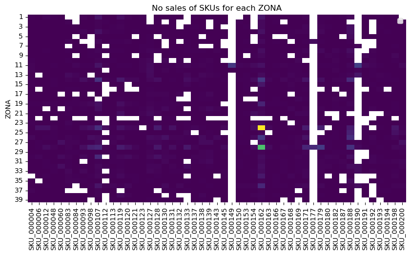

```python
# plot df_skus_zeros.T and color ONLY the 0's
fig, ax = plt.subplots(figsize=(10, 5))
sns.heatmap(df_skus_zeros.T, cmap='viridis', cbar=False)
plt.title('No sales of SKUs for each ZONA')
# y ticks 90 degrees
plt.yticks(rotation=0)
# show cmap legend
plt.legend()
# show plot
plt.show()
```

## Alternating Least Squares

We used a BSc project to apply the two-step ALS algorithm to find the best recommendation using matrix factorization. All is implemented only using `numpy`.

```python
# implement the nDCG metric at P for matrix X and matrix X_hat
def ndcg_at_p(X, X_hat, P):
    # copy
    X = X.copy()
    X_hat = X_hat.copy()
    # get the top P sales for each zone
    top_P = X_hat.apply(lambda x: x.nlargest(P).index.tolist(), axis=1)
    # get the top P sales for each zone
    top_P_true = X.apply(lambda x: x.nlargest(P).index.tolist(), axis=1)
    # get the ideal DCG
    ideal_dcg = top_P_true.apply(lambda x: sum([1 / np.log2(i + 2) for i in range(P)]))
    # get the DCG
    dcg = top_P.apply(lambda x: sum([1 / np.log2(i + 2) if x[i] in top_P_true.iloc[i] else 0 for i in range(P)]))
    # get the nDCG
    ndcg = dcg / ideal_dcg
    return ndcg
```

### example

```python
import utils.Descenso2Pasos as d2p

# Example matrix X with NaN values
X = np.array([
    [5, np.nan, 4, np.nan, 1],
    [np.nan, 3, np.nan, 2, np.nan],
    [4, np.nan, 5, np.nan, 3],
    [np.nan, 2, np.nan, 1, np.nan]
])

# apply the 2 steps descent algorithm
np.random.seed(8)
k = 8
lambd = 0.1
maxiter = 100
tol = 1
W, H, time, cost = d2p.gradient2steps(X, k, lambd, maxiter, tol)
```

```
Iteración-0.
  Costo Medio: 1085.257
  Costo de Diferencias: 10823.979
  Costo de U: 13.008
  Costo de V: 15.585
  Costo Total: 10852.572
Han transcurrido 0.001 segundos
En columnas
En renglones


Iteración-1.
  Costo Medio: 0.561
  Costo de Diferencias: 1.79
  Costo de U: 3.714
  Costo de V: 0.107
  Costo Total: 5.61
Han transcurrido 0.022 segundos
En columnas
En renglones


Iteración-2.
  Costo Medio: 0.422
  Costo de Diferencias: 0.914
  Costo de U: 3.114
  Costo de V: 0.195
  Costo Total: 4.223
Han transcurrido 0.043 segundos
En columnas
En renglones


Iteración-3.
  Costo Medio: 0.331
  Costo de Diferencias: 0.297
  Costo de U: 2.742
  Costo de V: 0.27
  Costo Total: 3.31
Han transcurrido 0.061 segundos
```

[output cut: 1045 more lines]

```
En columnas
En renglones


Iteración-99.
  Costo Medio: 0.155
  Costo de Diferencias: 0.043
  Costo de U: 0.762
  Costo de V: 0.744
  Costo Total: 1.549
Han transcurrido 1.968 segundos
En columnas
En renglones

Algoritmo de descenso en 2 pasos no convirgió
```

```python
# the approximation look correct
pd.DataFrame(W@H)
```

|  | 0 | 1 | 2 | 3 | 4 |
| --- | --- | --- | --- | --- | --- |
| 0 | 4.909964 | 0.001008 | 3.971731 | 0.000926 | 1.035477 |
| 1 | 0.000990 | 2.992880 | 0.000924 | 1.849702 | 0.000530 |
| 2 | 3.989822 | 0.001005 | 4.932579 | 0.000943 | 2.925513 |
| 3 | 0.000912 | 1.849702 | 0.000867 | 1.143179 | 0.000456 |

```python
# apply the nDCG metric to W@H and X
np.mean(ndcg_at_p(pd.DataFrame(X), pd.DataFrame(W@H), 3))
```

```
0.6913401592471553
```

#### recommendation

```python
# apply the 2 steps descent algorithm for df_skus_zeros.T
np.random.seed(8)
k = 32
lambd = 0.01
maxiter = 10
tol = 1e-3
W, H, time, cost = d2p.gradient2steps(df_skus_zeros.T.values, k, lambd, maxiter, tol)
```

```
Iteración-0.
  Costo Medio: 19333.205
  Costo de Diferencias: 33078995.178
  Costo de U: 52.119
  Costo de V: 65.663
  Costo Total: 33079112.96
Han transcurrido 0.004 segundos
En columnas
```

```
En renglones


Iteración-1.
  Costo Medio: 2.553
  Costo de Diferencias: 3925.801
  Costo de U: 441.015
  Costo de V: 0.645
  Costo Total: 4367.461
Han transcurrido 0.758 segundos
En columnas
En renglones


Iteración-2.
  Costo Medio: 0.519
  Costo de Diferencias: 473.323
  Costo de U: 414.938
  Costo de V: 0.593
  Costo Total: 888.853
Han transcurrido 1.359 segundos
En columnas
En renglones


Iteración-3.
  Costo Medio: 0.426
  Costo de Diferencias: 338.935
  Costo de U: 389.927
  Costo de V: 0.591
  Costo Total: 729.452
Han transcurrido 1.959 segundos
En columnas
En renglones


Iteración-4.
  Costo Medio: 0.384
  Costo de Diferencias: 287.521
  Costo de U: 368.543
```

[output cut: 47 more lines]

```
En columnas
En renglones


Iteración-9.
  Costo Medio: 0.284
  Costo de Diferencias: 182.037
  Costo de U: 302.836
  Costo de V: 0.609
  Costo Total: 485.482
Han transcurrido 5.092 segundos
En columnas
En renglones

Algoritmo de descenso en 2 pasos no convirgió
```

```python
df_skus_zeros.T
```

| ZONA | SKU_000004 | SKU_000006 | SKU_000012 | SKU_000048 | SKU_000060 | SKU_000083 | SKU_000084 | SKU_000093 | SKU_000098 | SKU_000107 | ... | SKU_000182 | SKU_000187 | SKU_000188 | SKU_000190 | SKU_000191 | SKU_000192 | SKU_000193 | SKU_000194 | SKU_000198 | SKU_000200 |
| --- | --- | --- | --- | --- | --- | --- | --- | --- | --- | --- | --- | --- | --- | --- | --- | --- | --- | --- | --- | --- | --- |
| 1 | 2.770269 | 0.478408 | 6.569821 | 1.697337 | 0.506494 | NaN | NaN | 3.973357 | 0.433813 | 2.281028e+01 | ... | 0.418297 | 1.677603 | 6.712063 | NaN | 1.759146 | 1.293314 | 2.408767 | 0.459970 | 2.359301 | NaN |
| 2 | 0.595710 | 0.041274 | 0.108619 | 0.190479 | 0.119700 | 3.630330 | NaN | 0.155698 | 0.381249 | 4.726417e+00 | ... | 0.777112 | 0.098419 | NaN | NaN | 0.531473 | NaN | 0.264903 | 0.107979 | 0.632653 | 0.853632 |
| 3 | 0.315957 | 0.862358 | 1.046348 | 0.811787 | 0.497736 | 0.101819 | 0.196060 | 1.179903 | 0.922547 | 4.334944e+00 | ... | 1.264701 | 0.956975 | 14.801203 | NaN | 0.346763 | NaN | 1.820579 | 0.888135 | 0.407213 | 1.131421 |
| 4 | 0.104755 | 1.642425 | 1.561254 | 0.608474 | 0.373605 | 1.518735 | 0.534028 | 5.947743 | 0.833875 | 1.663547e+01 | ... | 0.646254 | 0.478512 | 16.046328 | NaN | 0.124046 | NaN | 0.541028 | 2.645447 | 0.429814 | 0.487546 |
| 5 | 0.285202 | 0.033597 | 0.051095 | 0.045507 | 0.108830 | 0.574251 | NaN | 0.336254 | NaN | 1.246209e-01 | ... | 0.070261 | NaN | 11.464339 | NaN | 0.182338 | 1.365828 | 0.085603 | 0.262775 | 0.271253 | 0.764751 |
| 6 | 1.425880 | 0.196311 | 0.301178 | 0.201309 | 0.438563 | 4.816061 | 0.300579 | NaN | NaN | 7.885758e+00 | ... | 0.595663 | 0.492145 | 2.538861 | NaN | NaN | NaN | 0.275166 | 0.212128 | 1.169236 | 0.714186 |
| 7 | 0.377118 | 0.125277 | 0.170137 | 0.337116 | 0.106817 | NaN | 1.094807 | 0.097053 | NaN | 1.121648e+00 | ... | 0.494258 | 1.177423 | 0.313139 | 7.862011 | NaN | NaN | 0.481540 | 0.157665 | 2.639629 | 0.569060 |
| 8 | 0.186195 | 0.213508 | 2.101911 | 1.102176 | 1.249550 | 2.569130 | 0.679855 | 0.176316 | 2.931165 | 6.162019e+00 | ... | 5.049502 | 3.150935 | 13.584641 | NaN | NaN | 4.584567 | 0.444651 | 0.443136 | 0.101647 | 0.365749 |
| 9 | 1.028291 | 0.014716 | 0.134499 | 0.325096 | 0.072567 | 1.408715 | NaN | 0.032351 | 3.190101 | 2.213306e+00 | ... | 2.311335 | 0.094531 | 5.571920 | NaN | 7.062595 | 1.912830 | 0.475613 | 0.580216 | 7.036827 | 0.086411 |
| 10 | 1.877835 | 0.060504 | 0.070396 | 0.240431 | 0.047894 | 2.932211 | 1.362397 | 0.161754 | 0.069708 | 4.920427e+00 | ... | 4.486269 | 1.156220 | 1.228481 | NaN | 0.276175 | 3.818093 | 0.278766 | 0.164244 | 2.585285 | 0.111334 |
| 11 | 3.600988 | 0.834752 | 0.071287 | 1.961130 | 0.228082 | 1.177970 | 5.912888 | 3.236378 | 2.828988 | 2.040961e+01 | ... | 2.119197 | 0.665996 | 6.268098 | 78.448036 | 8.972704 | 6.320593 | 2.076044 | 0.230062 | 0.974698 | 8.065303 |
| 12 | 3.550769 | 0.136421 | 0.106281 | 0.381930 | 0.545870 | 0.471211 | 1.639430 | 0.277031 | 0.426833 | 6.596996e-01 | ... | 3.472482 | 0.383981 | 1.675770 | 5.926075 | 0.160824 | 2.210928 | 0.580886 | 0.331219 | 0.809201 | 0.883368 |
| 13 | 1.295052 | NaN | 0.188667 | 1.497158 | 0.107635 | 10.778872 | 5.543020 | 0.061467 | NaN | 9.203527e-01 | ... | 1.307313 | 2.565802 | 4.971334 | 23.620999 | 0.043723 | 3.108286 | 3.799810 | 1.725557 | 1.606611 | 0.418682 |
| 14 | 2.972554 | 0.468617 | 1.232486 | 1.948071 | 0.253263 | 4.049792 | 1.809509 | 14.066596 | 4.735043 | 5.754773e+01 | ... | 3.850232 | 3.402178 | 48.459623 | NaN | 2.405744 | 1.454671 | 3.270826 | 3.016631 | 3.028978 | 0.557945 |
| 15 | 1.761154 | 0.034063 | 0.168883 | 2.103742 | 0.108850 | 1.174997 | 0.487799 | 1.030376 | 0.377234 | 1.583073e-01 | ... | 1.467063 | 0.677464 | 1.240620 | NaN | 0.241120 | 2.016981 | 1.299416 | 1.023695 | 0.383189 | 0.125255 |
| 16 | 0.599265 | NaN | 0.027902 | 0.253016 | 0.036283 | 3.027296 | 1.866449 | 0.014705 | 0.134258 | 2.287154e-01 | ... | NaN | 0.387933 | 0.620644 | NaN | NaN | 1.625367 | 4.220364 | NaN | 0.605884 | 0.265046 |
| 17 | 0.024174 | 0.195137 | 0.143625 | 0.338707 | NaN | 1.986239 | NaN | 0.630493 | NaN | 1.017902e+00 | ... | 0.414046 | NaN | 2.212095 | NaN | 0.459538 | 0.674772 | 0.403402 | 1.836970 | 0.280494 | 1.049456 |
| 18 | 1.445183 | 0.051533 | 0.461385 | 0.093582 | 0.121584 | 1.002111 | 2.058977 | 0.280008 | 0.234995 | NaN | ... | 3.891181 | 1.999151 | 1.841253 | NaN | 0.068459 | 1.165446 | 0.201155 | 0.300242 | 0.188127 | 0.260255 |
| 19 | 1.895318 | 1.929934 | 4.181988 | 1.965412 | 0.437859 | 3.136593 | 1.646129 | 3.813010 | 7.617188 | 1.697399e+01 | ... | 2.819348 | 0.567186 | 5.529431 | NaN | 0.221914 | 0.914803 | 0.402316 | 0.225674 | 1.910203 | 0.772071 |
| 20 | 0.790094 | 0.028551 | NaN | 0.571855 | NaN | 3.365729 | 0.401184 | 3.235001 | 0.703506 | 1.381098e+01 | ... | 1.887532 | 2.393570 | 2.485343 | NaN | 1.004806 | 3.767174 | 0.100031 | 0.478813 | 2.280551 | 1.077972 |
| 21 | 0.692027 | 0.158396 | 1.031347 | 0.097505 | 0.083209 | 3.044052 | 1.174910 | 0.318240 | 0.875337 | 2.938816e+00 | ... | NaN | 1.151750 | NaN | NaN | 1.768367 | NaN | NaN | 3.300350 | 1.170440 | 0.434969 |
| 22 | 0.217971 | NaN | 0.271220 | NaN | 0.554536 | 0.421209 | NaN | NaN | 0.359319 | NaN | ... | NaN | 0.098419 | 0.293649 | NaN | NaN | NaN | 2.719309 | 0.311118 | NaN | 1.192151 |
| 23 | 2.116809 | 0.490524 | 1.454733 | 1.609191 | 0.387585 | 5.785290 | 1.330848 | 0.084028 | 0.716339 | 1.476535e+00 | ... | 0.485431 | 0.494065 | 0.158817 | NaN | NaN | 1.317503 | 0.968811 | 0.907536 | 0.502374 | 1.577624 |
| 24 | 0.253829 | 17.017256 | 17.930954 | 4.177513 | 0.369208 | 3.228805 | 1.328529 | 12.503250 | 19.716240 | 5.555496e+01 | ... | 0.218926 | 0.491564 | 31.019310 | NaN | 6.849544 | NaN | 2.261104 | 0.720087 | 23.129201 | 2.384668 |
| 25 | 0.280767 | 0.042901 | 0.115122 | 2.269796 | 0.044629 | 0.810624 | 0.817449 | 0.064702 | 0.372255 | 3.740755e-08 | ... | 1.680120 | 1.180499 | 38.844897 | NaN | 2.553566 | 1.120956 | 0.904912 | 0.331221 | 17.742720 | 7.711947 |
| 26 | 7.083275 | 1.478815 | 2.523573 | 2.541106 | 0.519673 | 4.529662 | 2.395618 | 0.095389 | 13.713068 | 1.085921e+01 | ... | 2.614586 | 0.677660 | 55.535727 | NaN | 2.467267 | 5.062928 | 0.941869 | 3.252475 | 5.490340 | 0.677638 |
| 27 | 1.361867 | 2.200794 | 0.100749 | 0.684122 | 15.990368 | 4.110186 | 3.664064 | 0.535391 | 1.677840 | 9.922962e+00 | ... | 0.434127 | 0.198807 | 4.289483 | 3.864331 | 0.022751 | 2.076748 | 0.077897 | 1.594598 | 0.580376 | 16.890779 |
| 28 | 0.448604 | 2.939551 | 12.865881 | 3.319216 | 1.386725 | 4.513885 | 0.598490 | 13.297257 | 37.327424 | 4.509247e+01 | ... | 0.638559 | 0.392081 | 57.727239 | 9.819483 | 2.571429 | 0.540539 | 2.334847 | 1.120739 | 8.212966 | 5.256192 |
| 29 | 1.567095 | 0.107742 | 0.369357 | 0.804414 | 0.018142 | 2.748212 | 2.183580 | 0.346103 | 0.156663 | 5.102866e-01 | ... | 1.902254 | 2.843064 | 2.391054 | NaN | NaN | 0.545303 | 0.469619 | 1.235202 | 0.301947 | 3.089799 |
| 30 | 2.139913 | 6.470623 | 0.094081 | 0.228338 | 9.935918 | 4.020870 | 1.097263 | 7.153318 | 0.591334 | 4.918393e+01 | ... | 4.227702 | 0.384310 | 16.317844 | NaN | NaN | 5.293154 | 2.075907 | 0.507368 | 1.496022 | 0.756007 |
| 31 | 0.133245 | 0.420599 | 2.945202 | 0.582005 | 1.176370 | 2.262708 | 0.503345 | NaN | 0.756622 | 1.886727e+00 | ... | 1.799108 | 3.818603 | 1.080879 | NaN | 1.952478 | 5.976520 | 3.030659 | 1.894636 | 4.450976 | 4.987268 |
| 32 | 0.237703 | 0.367494 | 1.890886 | 1.748536 | 13.811467 | 3.162509 | 1.207987 | 2.010573 | 0.598044 | 8.116179e+00 | ... | 0.227012 | 2.413824 | 12.978197 | 11.904271 | 0.376825 | 0.345528 | 0.421489 | 0.690251 | 1.554027 | 4.246459 |
| 33 | 1.011045 | 0.125822 | 0.476134 | 1.984977 | 1.229599 | 6.595337 | 0.388223 | 7.099603 | 1.383923 | 6.212725e+00 | ... | 0.215696 | 1.484377 | 4.731276 | 11.624724 | 1.146622 | 3.539168 | 0.443672 | 0.315331 | 2.648890 | 0.317964 |
| 34 | NaN | 0.376550 | 2.187777 | 0.857126 | 0.204494 | 4.141997 | 3.162861 | 0.875740 | 1.770553 | 7.846643e+00 | ... | 1.515357 | NaN | 1.637231 | NaN | NaN | NaN | 0.722452 | 0.349073 | 4.371809 | 0.880247 |
| 35 | 0.679337 | NaN | 0.179479 | 0.496978 | 1.313470 | 4.404961 | 3.365908 | 1.818120 | 0.844401 | 5.910227e-01 | ... | 0.458665 | NaN | 10.315352 | NaN | NaN | 1.340741 | 1.853427 | 0.221467 | 1.071243 | 0.310483 |
| 36 | 0.543244 | 0.620300 | 2.209087 | 1.012920 | 0.145065 | 2.157638 | NaN | 0.712802 | 2.975754 | 2.230091e+01 | ... | 1.045421 | 1.956994 | 4.164130 | 13.463987 | 3.036401 | NaN | 1.426184 | 0.976882 | 3.567833 | 4.304673 |
| 37 | 4.844704 | 0.017032 | 0.155656 | 1.211985 | 0.052248 | NaN | NaN | NaN | 0.139416 | 3.338696e+00 | ... | 0.628884 | NaN | 0.312054 | NaN | 0.299884 | NaN | 2.275936 | 1.803696 | 0.202734 | 0.468515 |
| 38 | 0.609190 | 0.178030 | 1.306089 | 0.205701 | 0.199559 | 0.894529 | 0.661357 | 0.452913 | 0.692191 | 4.253023e+00 | ... | 0.944041 | 0.570017 | 0.308310 | NaN | 0.081519 | NaN | 0.503433 | 1.247928 | 1.632865 | 1.474344 |
| 39 | 0.568576 | 0.855580 | 0.672588 | 0.021744 | 0.561104 | 0.610753 | 0.100037 | 0.886293 | NaN | 1.215459e+00 | ... | 0.619966 | 0.196839 | 0.293649 | NaN | NaN | 0.410489 | NaN | 1.158577 | 1.293774 | 0.657999 |

39 rows × 51 columns

```python
df_skus_filled = pd.DataFrame(W@H, index=df_skus_zeros.columns, columns=df_skus_zeros.index)
df_skus_filled
```

| ZONA | SKU_000004 | SKU_000006 | SKU_000012 | SKU_000048 | SKU_000060 | SKU_000083 | SKU_000084 | SKU_000093 | SKU_000098 | SKU_000107 | ... | SKU_000182 | SKU_000187 | SKU_000188 | SKU_000190 | SKU_000191 | SKU_000192 | SKU_000193 | SKU_000194 | SKU_000198 | SKU_000200 |
| --- | --- | --- | --- | --- | --- | --- | --- | --- | --- | --- | --- | --- | --- | --- | --- | --- | --- | --- | --- | --- | --- |
| 1 | 2.256020 | 0.886981 | 5.221802 | 1.254694 | 0.679160 | 0.089417 | 0.060575 | 3.224593 | 1.225399 | 22.637167 | ... | 1.208944 | 2.128788 | 6.619214 | 0.000206 | 0.956000 | 1.509109 | 3.010992 | 0.739102 | 2.444762 | 0.300862 |
| 2 | 0.395724 | 0.525074 | 0.520787 | 0.646719 | 0.257605 | 3.186124 | 0.420427 | 1.090381 | 0.434605 | 4.646374 | ... | 0.789554 | 0.308147 | 0.243445 | 0.061343 | 0.187702 | 0.566485 | 0.101753 | 0.169764 | 0.648930 | 0.777265 |
| 3 | 0.679524 | 0.523942 | 1.370470 | 0.586869 | 0.257447 | 0.426208 | 0.474349 | 1.424725 | 1.290570 | 4.382867 | ... | 0.862996 | 1.052128 | 14.719207 | 0.014785 | 0.323347 | 0.646420 | 1.116801 | 0.748888 | 0.408775 | 1.010973 |
| 4 | 0.424017 | 2.720510 | 1.226437 | 0.556822 | 0.301318 | 1.483730 | 1.018538 | 6.383750 | 1.272975 | 16.087744 | ... | 0.792540 | 0.412934 | 15.882896 | 0.028162 | 0.122622 | 0.247395 | 1.084085 | 0.901945 | 0.439210 | 0.404978 |
| 5 | 0.164217 | 0.060430 | 0.144888 | 0.069556 | 0.081999 | 0.699224 | 0.340248 | 0.507481 | 0.139681 | 0.769799 | ... | 0.354150 | 0.348162 | 11.288351 | 0.008209 | 0.166749 | 0.895413 | 0.526968 | 0.390226 | 0.277582 | 0.837909 |
| 6 | 0.962593 | 0.382363 | 0.130099 | 0.313945 | 0.408828 | 4.313565 | 0.619984 | 0.613920 | 0.044500 | 7.807264 | ... | 0.804259 | 0.440366 | 2.492982 | 0.039133 | 0.165019 | 0.291368 | 0.643432 | 0.535492 | 1.130205 | 0.807407 |
| 7 | 0.342046 | 0.142265 | 0.207576 | 0.424447 | 0.051844 | 0.580020 | 0.501718 | 0.076822 | 0.031718 | 1.069285 | ... | 0.679444 | 0.697135 | 0.402780 | 7.717863 | 0.499328 | 0.416720 | 0.344553 | 0.370804 | 2.487895 | 0.616519 |
| 8 | 0.559198 | 0.798785 | 1.032328 | 0.764883 | 1.280823 | 2.707621 | 0.859954 | 1.377861 | 2.556319 | 5.890480 | ... | 4.745595 | 2.660802 | 13.562829 | 0.221445 | 0.380664 | 5.437723 | 0.471639 | 0.647826 | 0.388098 | 0.481453 |
| 9 | 0.955585 | 0.078472 | 0.306747 | 0.421501 | 0.136394 | 1.271198 | 0.294194 | 0.098234 | 3.634303 | 2.147509 | ... | 2.372795 | 0.413200 | 5.569995 | 0.007609 | 6.596294 | 1.469978 | 0.604132 | 0.496185 | 6.989210 | 0.153913 |
| 10 | 1.814454 | 0.282543 | 0.581202 | 0.466158 | 0.105665 | 2.626491 | 1.907643 | 0.515216 | 0.216827 | 4.933140 | ... | 4.640790 | 1.476415 | 1.198008 | 0.000044 | 0.519406 | 3.146233 | 0.453837 | 0.629279 | 2.470059 | 0.179988 |
| 11 | 3.537763 | 1.609013 | 0.676904 | 1.925057 | 0.470400 | 1.369428 | 5.813444 | 3.149786 | 2.869391 | 20.014952 | ... | 2.089716 | 1.059508 | 6.255625 | 76.815583 | 8.996085 | 6.271328 | 2.043942 | 0.584650 | 1.017924 | 7.708314 |
| 12 | 3.275182 | 0.076003 | 0.277544 | 0.599763 | 0.191036 | 1.077229 | 1.528674 | 0.059494 | 0.146579 | 1.139246 | ... | 3.172379 | 0.769014 | 1.637294 | 5.824183 | 0.491306 | 2.429591 | 0.677169 | 0.913665 | 0.720558 | 1.020896 |
| 13 | 1.297103 | 0.260840 | 0.343625 | 1.665624 | 0.201445 | 9.767998 | 5.293098 | 0.993037 | 0.609744 | 0.817552 | ... | 1.705247 | 2.050976 | 4.925042 | 23.136546 | 0.211128 | 3.224536 | 3.603278 | 1.375573 | 1.549033 | 0.509508 |
| 14 | 2.829339 | 1.994980 | 1.844967 | 2.141956 | 0.285348 | 4.041293 | 1.791939 | 13.541602 | 4.941715 | 57.677878 | ... | 3.232987 | 3.046592 | 48.237779 | 0.000409 | 2.554843 | 1.930647 | 2.830635 | 2.914720 | 2.977429 | 0.664664 |
| 15 | 1.605505 | 0.391417 | 0.977736 | 1.150285 | 0.017961 | 2.228777 | 1.353087 | 0.114127 | 0.706802 | 0.764458 | ... | 1.008823 | 1.050848 | 1.484298 | 0.000622 | 0.220289 | 1.489019 | 1.529969 | 0.599054 | 0.538595 | 0.140769 |
| 16 | 0.794000 | 0.029980 | 0.722889 | 0.428451 | 0.184329 | 3.044451 | 1.998490 | 0.171538 | 0.221563 | 0.513307 | ... | 0.286151 | 0.956538 | 0.770172 | 0.002151 | 0.209666 | 0.892461 | 2.214423 | 0.624664 | 0.543427 | 0.130348 |
| 17 | 0.382362 | 0.422611 | 0.106383 | 0.396476 | 0.345487 | 2.396190 | 0.523477 | 0.513482 | 0.348588 | 1.459937 | ... | 0.218651 | 0.675036 | 2.207475 | 0.020183 | 0.361896 | 0.799300 | 0.165762 | 1.197422 | 0.315884 | 0.827031 |
| 18 | 1.490389 | 0.178218 | 0.587670 | 0.134351 | 0.125538 | 0.968821 | 2.050995 | 0.533915 | 0.503887 | 0.658631 | ... | 3.618200 | 0.814423 | 1.934312 | 0.000404 | 0.084045 | 1.229888 | 0.688135 | 0.458764 | 0.198692 | 0.238514 |
| 19 | 2.026403 | 2.566908 | 3.745905 | 1.721278 | 0.157984 | 3.229101 | 1.093394 | 3.250412 | 6.063863 | 16.862981 | ... | 2.125997 | 0.395299 | 5.492302 | 0.458099 | 1.507445 | 1.149248 | 0.621761 | 0.537271 | 1.900417 | 0.913108 |
| 20 | 0.891314 | 0.696458 | 0.111503 | 0.377024 | 0.099296 | 3.296630 | 0.438879 | 2.612110 | 0.677442 | 12.871880 | ... | 1.672257 | 1.362890 | 3.337048 | 0.210459 | 0.786527 | 4.307545 | 0.365750 | 0.870487 | 2.274265 | 1.191084 |
| 21 | 0.629863 | 0.224826 | 1.022432 | 0.270175 | 0.244353 | 2.643618 | 1.003334 | 0.956206 | 0.851381 | 2.898915 | ... | 1.091329 | 1.697280 | 0.511348 | 0.033567 | 1.298641 | 0.472797 | 0.118012 | 3.001070 | 1.200507 | 0.319391 |
| 22 | 0.906273 | 0.209971 | 0.603394 | 0.289707 | 0.261512 | 0.786305 | 0.525009 | 0.023997 | 0.067044 | 0.475878 | ... | 0.407743 | 0.479403 | 0.332577 | 0.014576 | 0.126302 | 0.785378 | 1.002946 | 0.308893 | 0.051641 | 0.944477 |
| 23 | 2.009638 | 0.381949 | 0.760039 | 1.383807 | 0.493116 | 5.234718 | 1.066388 | 1.016836 | 0.772371 | 1.412872 | ... | 0.588226 | 0.749712 | 0.666348 | 0.034019 | 0.418744 | 1.131319 | 0.980799 | 1.109720 | 0.456291 | 1.704733 |
| 24 | 0.351814 | 16.624690 | 17.790517 | 4.199316 | 0.345774 | 3.171482 | 1.300969 | 12.489272 | 19.874059 | 55.631074 | ... | 0.530689 | 0.356591 | 30.897214 | 0.012210 | 6.349746 | 0.327618 | 2.077869 | 0.909595 | 22.704434 | 2.347425 |
| 25 | 0.345414 | 0.127974 | 0.137793 | 2.125356 | 0.545600 | 0.775020 | 0.959208 | 0.002568 | 1.516148 | 0.893531 | ... | 1.062056 | 1.083933 | 38.433075 | 0.100294 | 2.602115 | 0.789255 | 0.645893 | 0.552049 | 17.274618 | 7.322946 |
| 26 | 6.894297 | 1.362937 | 2.509725 | 2.547509 | 0.621996 | 4.305897 | 2.262335 | 0.931210 | 13.641554 | 10.747416 | ... | 2.682177 | 1.445857 | 55.648631 | 0.096934 | 2.337093 | 4.801993 | 1.758494 | 2.979847 | 5.440352 | 0.664137 |
| 27 | 1.222352 | 2.136289 | 0.549938 | 0.654188 | 15.214124 | 4.046257 | 3.324374 | 1.146479 | 1.429596 | 9.627126 | ... | 0.792229 | 0.651913 | 4.278503 | 3.775169 | 0.073261 | 1.737741 | 0.522666 | 1.720437 | 0.586963 | 16.299270 |
| 28 | 0.748032 | 3.065367 | 12.899560 | 3.340481 | 1.372908 | 4.740054 | 0.915616 | 13.052926 | 37.639265 | 45.177966 | ... | 0.966008 | 1.310132 | 57.382764 | 9.791279 | 2.641806 | 0.501066 | 2.447735 | 1.556220 | 8.227678 | 5.216292 |
| 29 | 1.604500 | 0.336569 | 0.256953 | 0.773461 | 0.244095 | 2.701284 | 1.746594 | 0.272024 | 0.619404 | 1.185432 | ... | 1.154759 | 1.290274 | 2.426403 | 0.043231 | 0.134704 | 1.308943 | 1.119526 | 1.632092 | 0.333891 | 3.138408 |
| 30 | 2.241958 | 4.412382 | 1.435642 | 0.568081 | 9.953886 | 3.720620 | 1.249367 | 7.357689 | 1.146323 | 48.883235 | ... | 4.270842 | 1.414186 | 16.731434 | 0.200507 | 0.227608 | 4.080975 | 2.128725 | 0.804452 | 1.419135 | 0.903210 |
| 31 | 0.419302 | 0.321219 | 3.736192 | 0.856728 | 1.086911 | 2.116850 | 0.529272 | 0.743079 | 0.632220 | 2.452135 | ... | 2.383132 | 3.518567 | 1.196176 | 0.069266 | 2.276420 | 5.455402 | 2.623943 | 1.321962 | 4.296121 | 4.832211 |
| 32 | 0.375859 | 1.701701 | 1.528339 | 1.913382 | 13.274246 | 3.031449 | 1.385849 | 1.774263 | 0.794834 | 8.098423 | ... | 0.569403 | 1.737334 | 12.874388 | 11.671816 | 0.444456 | 1.124975 | 0.919386 | 0.468731 | 1.504114 | 4.078734 |
| 33 | 0.853086 | 0.612228 | 0.853636 | 1.518067 | 1.182601 | 6.777779 | 0.842227 | 5.744005 | 1.248434 | 6.128841 | ... | 0.670504 | 1.121754 | 5.047110 | 11.377613 | 1.152723 | 2.677139 | 0.846053 | 0.732066 | 2.642515 | 0.255213 |
| 34 | 0.263388 | 0.592209 | 1.303588 | 0.536399 | 0.110552 | 4.179430 | 2.880858 | 1.581513 | 1.611158 | 7.725086 | ... | 0.668971 | 0.722227 | 1.728682 | 0.021980 | 0.706143 | 0.341076 | 2.190921 | 0.524358 | 4.203669 | 0.926029 |
| 35 | 0.647923 | 0.190433 | 0.458317 | 0.810383 | 1.120023 | 4.444868 | 2.017600 | 1.195124 | 0.910304 | 0.955264 | ... | 1.039134 | 0.694120 | 10.244809 | 0.021004 | 0.215163 | 0.999368 | 1.206132 | 0.536645 | 0.989852 | 0.341146 |
| 36 | 0.522075 | 1.238506 | 1.870045 | 0.657302 | 0.369610 | 1.909744 | 0.597634 | 1.659262 | 2.522592 | 22.118763 | ... | 0.940265 | 1.187615 | 4.200740 | 13.197784 | 3.306052 | 0.436631 | 0.943396 | 1.116220 | 3.524484 | 4.347711 |
| 37 | 4.936715 | 0.534538 | 0.540426 | 1.485406 | 0.025450 | 0.231148 | 0.068187 | 0.518357 | 0.266545 | 3.155696 | ... | 0.603826 | 0.249359 | 0.823558 | 0.004064 | 0.130734 | 0.101026 | 1.330615 | 1.400120 | 0.206129 | 0.347397 |
| 38 | 0.514015 | 0.355810 | 1.610314 | 0.403264 | 0.110948 | 1.604377 | 1.106785 | 0.941278 | 0.995257 | 4.916101 | ... | 0.803548 | 0.333700 | 0.309140 | 0.013779 | 0.450547 | 0.335444 | 0.743177 | 1.221313 | 1.514706 | 1.319187 |
| 39 | 0.697658 | 0.427918 | 0.158603 | 0.234884 | 0.419824 | 0.725650 | 0.131722 | 0.371391 | 0.248791 | 1.412705 | ... | 0.397375 | 0.296920 | 0.395849 | 0.013179 | 0.267672 | 0.553223 | 0.177116 | 0.752879 | 1.235167 | 0.724420 |

39 rows × 51 columns

```python
# nDCG metric
np.mean(ndcg_at_p(df_skus.T, df_skus_filled.T, 3))
```

```
0.19125940800356964
```

```
No artists with labels found to put in legend.  Note that artists whose label start with an underscore are ignored when legend() is called with no argument.
```

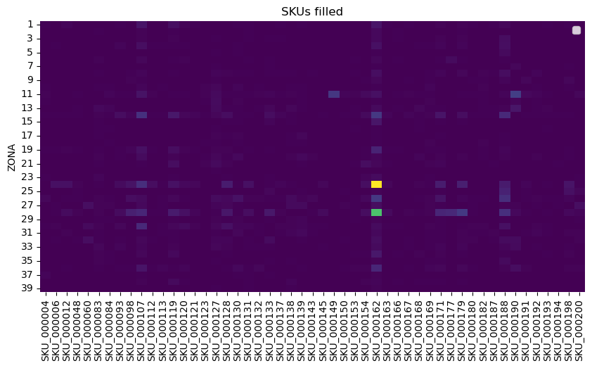

```python
# plot df_skus_filled.T and color ONLY the 0's
fig, ax = plt.subplots(figsize=(10, 5))
sns.heatmap(df_skus_filled, cmap='viridis', cbar=False)
plt.title('SKUs filled')
# y ticks 90 degrees
plt.yticks(rotation=0)
# show cmap legend
plt.legend()
# show plot
plt.show()
```

```python
# get top 3 recommendations for each zone
top3_rec = df_skus_filled[nan_indices].apply(lambda x: x.nlargest(3).index.tolist(), axis=1)
# explode top3 as columns
top3_rec = top3_rec.explode().reset_index().rename(columns={0: 'SKU'})
top3_rec
```

|  | ZONA | SKU |
| --- | --- | --- |
| 0 | 1 | SKU_000150 |
| 1 | 1 | SKU_000200 |
| 2 | 1 | SKU_000127 |
| 3 | 2 | SKU_000132 |
| 4 | 2 | SKU_000192 |
| ... | ... | ... |
| 112 | 38 | SKU_000133 |
| 113 | 38 | SKU_000112 |
| 114 | 39 | SKU_000169 |
| 115 | 39 | SKU_000143 |
| 116 | 39 | SKU_000191 |

117 rows × 2 columns

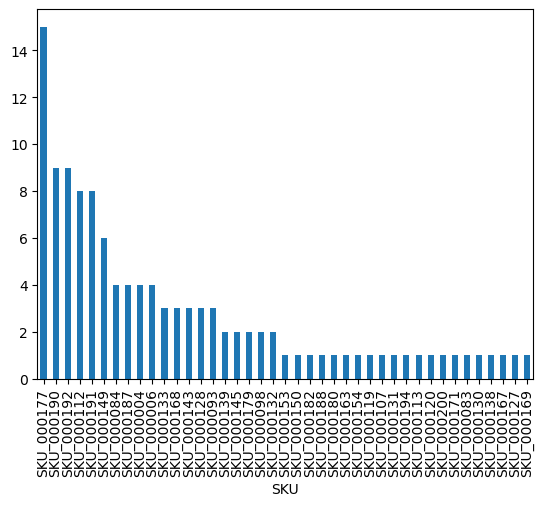

```python
# count the number of times each SKU is recommended
top3_rec['SKU'].value_counts().plot(kind='bar')
```

**takeaways**

1. The SKU 177 is the most recommended one, althought it is not the highest sales SKU. This could be due that has the less variance.
2. The model diversity is high, as there are various SKU's recommended.
3. Taking into consideration the forecast sells for each SKU, the model could be improved by adding a weight to the recommendations.